# Inflation effect on Stock Prices

### Kunwoo Kim

### 12.04.23

1. Fisher Effect
   - Expected inflation component
   - Unexpected inflation component
2. Expected Inflation on Stock Returns
   - Fama and Schwert 1977, *Asset Returns and Inflation*
   - Domian, Gilster, and Louton 1996, *Expected Inflation, Interest Rates, and Stock Returns*
   - Boudoukh and Richardson 1993, *Stock Returns and Inflation: A Long-Horizon Perspective*
3. My Research Analysis of Expected Inflation on Stock Prices
   - Different time frames
   - Different variables

## What is the Fisher Effect?

$$ (1 + i) = (1 + r) × (1 + π_{e}) $$

$$ i ≈ r + π_{e} $$

## Distinction

1. Expected Inflation Component
   - If expected inflation (**π**) increases, the nominal interest rate (**i**) will increase, assuming the real interest rate remains constant
   - Investment strategies: seek higher returns to offset the anticipated erosion of purchasing power
   - Stock prices: **negative** response, as investors demand a higher real return on their investment
2. Unexpected Inflation Component
   - Impacts the real interest rate (**r**). If nominal interest rates remain unchanged, the real interest rate effectively changes
   - Uncertainty: lead to market volatility
   - Stock prices: **negative** response, as investors react to the unforeseen changes in the economic landscape

## Expected Inflation vs Stock Returns Historical Evidence

## Fama and Schwert 1977, *Asset Returns and Inflation*

1. Data
   - Linear Regression: January 1953 ~ July 1971
   - $s_{vt}$ = Return to the value-weighted portfolio of **NYSE common stocks** for month **t**
   - $\beta_{1t}$ = Expected inflation rate for month **t**
   - Proxy for expected inflation? **One-month Treasury bill** set at the end on month **t-1**
2. Results

$$ s_{vt} = \underset{(0.0054)}{0.0234} - \underset{(1.85)}{5.50\beta_{1t}} + \hat{ε_{t}}, R_{adj}^2 = 0.03, S(\hat{ε_{t}}) = 0.0356 $$

3. "On the other hand, like others who have investigated the topic, for example, Linter (1975), Nelson (1976), and Jaffe and Mandelker (1976), we have no explanation for the negative relationship between common stock returns and the *expected* component of the inflation rate." (Fama and Schwert 1977)

## Domian, Gilster, and Louton 1996, *Expected Inflation, Interest Rates, and Stock Returns*

#### Augmenting Fama and Schwert by incorporating Time Series Analysis

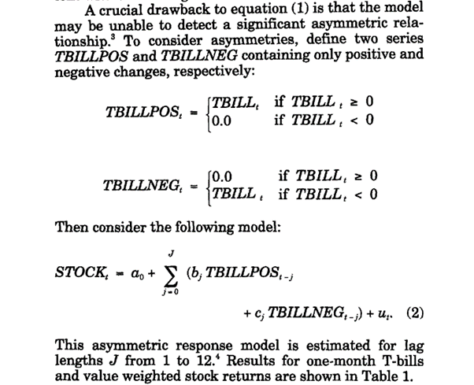

3. Visual Results

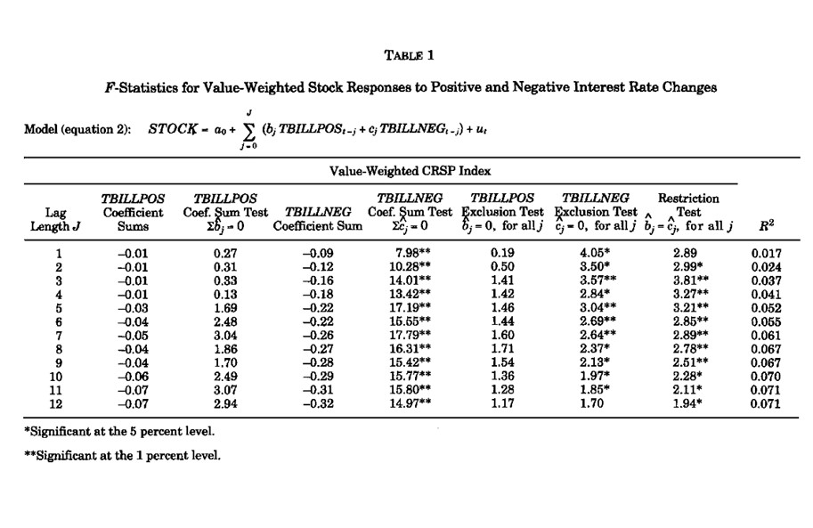

4. OLS Regressions can be strongly influenced by outliers
   - Results may have been influenced by the stock market crash of October 1987

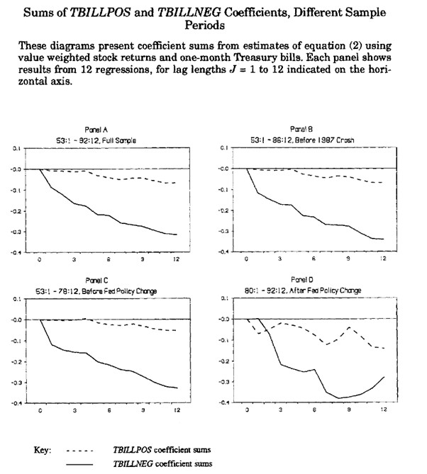

## Boudoukh and Richardson 1993, *Stock Returns and Inflation: A Long-Horizon Perspective*

#### Divergence from previous works by looking at long-term returns analysis

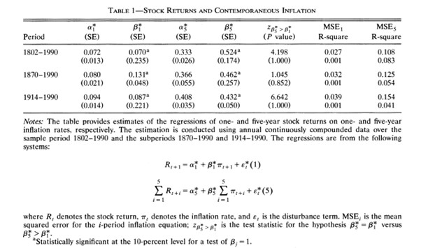

## Summary of the literature

1. Fama and Schwert
   - One month Expected Inflation (T-Bills) **linear regression on short-term** stock returns
   - Very Negative
2. Domian, Gilster, and Louton
   - One month Expected Inflation (T-bills) **times series regression on short-term** stock returns
   - Still negative
3. Boudoukh and Richardson
   - Inflation data (BLS data of 1 year inflation to 5 years) on long-term (1 to 5 years) stock returns
   - positive; contradicts previous works

## My question of Interest

#### What is the effect of Long-term inflation expectations (1 to 30 years) on short term (1 month) stock prices?

###### **Not Stock returns but prices

## OLS Regression

1. Data
   - Time frame: January 2014 to November 2023
   - Expected Inflation data: Federal Reserve of Cleveland's projections over a 30-year period (specifically 1-year, 5-year, 10-year, and 30-year Exp. Inflation)
   - Stock Prices: S&P 500 index MoM percent change

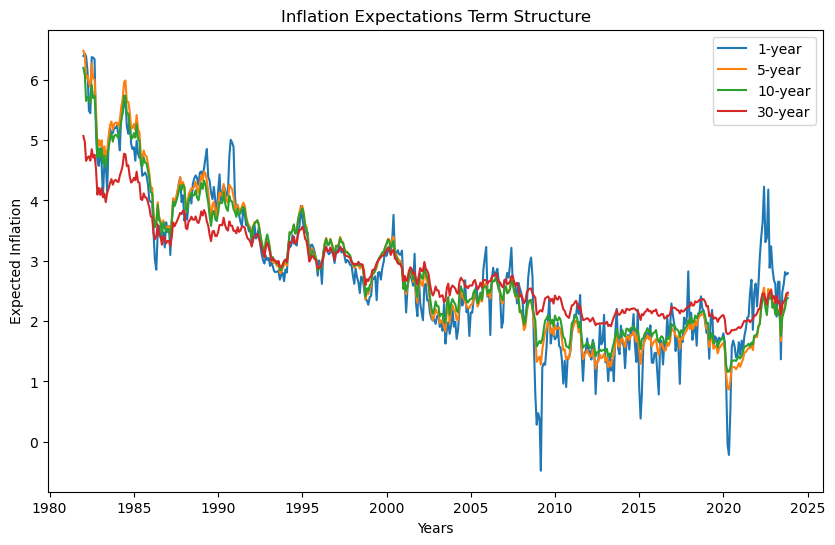

```
                              OLS Regression Results
==================================================================================
Dep. Variable:     Monthly_Percent_Change   R-squared:                       0.049
Model:                                OLS   Adj. R-squared:                  0.041
Method:                     Least Squares   F-statistic:                     6.003
Date:                    Mon, 04 Dec 2023   Prob (F-statistic):             0.0158
Time:                            05:45:10   Log-Likelihood:                -309.06
No. Observations:                     118   AIC:                             622.1
Df Residuals:                         116   BIC:                             627.7
Df Model:                               1
Covariance Type:                nonrobust
=============================================================================================
                                coef    std err          t      P>|t|      [0.025      0.975]
---------------------------------------------------------------------------------------------
const                         2.8738      0.892      3.220      0.002       1.106       4.641
1_year_Expected_Inflation    -1.0675      0.436     -2.450      0.016      -1.930      -0.205
==============================================================================
Omnibus:                       82.567   Durbin-Watson:                   1.926
Prob(Omnibus):                  0.000   Jarque-Bera (JB):              767.601
Skew:                          -2.189   Prob(JB):                    2.08e-167
Kurtosis:                      14.703   Cond. No.                         7.20
==============================================================================

Notes:
[1] Standard Errors assume that the covariance matrix of the errors is correctly specified.
```

```
                              OLS Regression Results
==================================================================================
Dep. Variable:     Monthly_Percent_Change   R-squared:                       0.051
Model:                                OLS   Adj. R-squared:                  0.043
Method:                     Least Squares   F-statistic:                     6.282
Date:                    Mon, 04 Dec 2023   Prob (F-statistic):             0.0136
Time:                            05:45:27   Log-Likelihood:                -308.93
No. Observations:                     118   AIC:                             621.9
Df Residuals:                         116   BIC:                             627.4
Df Model:                               1
Covariance Type:                nonrobust
=============================================================================================
                                coef    std err          t      P>|t|      [0.025      0.975]
---------------------------------------------------------------------------------------------
const                         4.7889      1.612      2.970      0.004       1.595       7.983
5_year_Expected_Inflation    -2.2689      0.905     -2.506      0.014      -4.062      -0.476
==============================================================================
Omnibus:                       87.183   Durbin-Watson:                   1.944
Prob(Omnibus):                  0.000   Jarque-Bera (JB):              914.040
Skew:                          -2.306   Prob(JB):                    3.30e-199
Kurtosis:                      15.831   Cond. No.                         12.2
==============================================================================

Notes:
[1] Standard Errors assume that the covariance matrix of the errors is correctly specified.
```

```
                              OLS Regression Results
==================================================================================
Dep. Variable:     Monthly_Percent_Change   R-squared:                       0.049
Model:                                OLS   Adj. R-squared:                  0.041
Method:                     Least Squares   F-statistic:                     5.967
Date:                    Mon, 04 Dec 2023   Prob (F-statistic):             0.0161
Time:                            05:45:36   Log-Likelihood:                -309.08
No. Observations:                     118   AIC:                             622.2
Df Residuals:                         116   BIC:                             627.7
Df Model:                               1
Covariance Type:                nonrobust
==============================================================================================
                                 coef    std err          t      P>|t|      [0.025      0.975]
----------------------------------------------------------------------------------------------
const                          5.8120      2.066      2.813      0.006       1.720       9.904
10_year_Expected_Inflation    -2.7257      1.116     -2.443      0.016      -4.936      -0.516
==============================================================================
Omnibus:                       88.329   Durbin-Watson:                   1.950
Prob(Omnibus):                  0.000   Jarque-Bera (JB):              942.670
Skew:                          -2.342   Prob(JB):                    2.00e-205
Kurtosis:                      16.030   Cond. No.                         16.0
==============================================================================

Notes:
[1] Standard Errors assume that the covariance matrix of the errors is correctly specified.
```

```
                              OLS Regression Results
==================================================================================
Dep. Variable:     Monthly_Percent_Change   R-squared:                       0.046
Model:                                OLS   Adj. R-squared:                  0.038
Method:                     Least Squares   F-statistic:                     5.610
Date:                    Mon, 04 Dec 2023   Prob (F-statistic):             0.0195
Time:                            05:45:52   Log-Likelihood:                -309.25
No. Observations:                     118   AIC:                             622.5
Df Residuals:                         116   BIC:                             628.0
Df Model:                               1
Covariance Type:                nonrobust
==============================================================================================
                                 coef    std err          t      P>|t|      [0.025      0.975]
----------------------------------------------------------------------------------------------
const                         10.6396      4.157      2.560      0.012       2.407      18.872
30_year_Expected_Inflation    -4.5491      1.921     -2.369      0.020      -8.353      -0.745
==============================================================================
Omnibus:                       88.643   Durbin-Watson:                   1.953
Prob(Omnibus):                  0.000   Jarque-Bera (JB):              944.864
Skew:                          -2.355   Prob(JB):                    6.69e-206
Kurtosis:                      16.038   Cond. No.                         35.3
==============================================================================

Notes:
[1] Standard Errors assume that the covariance matrix of the errors is correctly specified.
```

|  | Coefficients | p-value |
| --- | --- | --- |
| 1-year Exp. Inflation | -1.07 | 0.02 |
| 5-year Exp. Inflation | -2.27 | 0.01 |
| 10-year Exp. Inflation | -2.73 | 0.02 |
| 30-year Exp. Inflation | -4.55 | 0.02 |